# Bovine telomere dynamics and the association between telomere length and productive lifespan

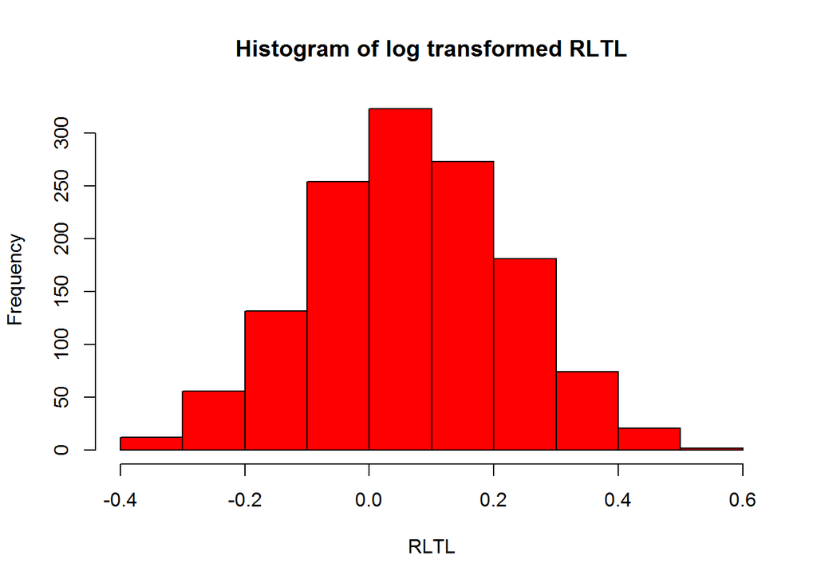

```r
#RLTL data is not perfectly normal distributed (but close to). THerefore, they are log transformed and tests for normality are repeated:
logTL<-log(data$QC_RTL)


h2<-hist(logTL, col="red", main="Histogram of log transformed RLTL", xlab="RLTL")
```

```r
# statistical tests for normal distribution of log transformed RTL measurements
shapiro.test(logTL)
```

```
##
##  Shapiro-Wilk normality test
##
## data:  logTL
## W = 0.99849, p-value = 0.2988
```

```r
ks.test(logTL, pnorm)
```

```
##
##  One-sample Kolmogorov-Smirnov test
##
## data:  logTL
## D = 0.37692, p-value < 2.2e-16
## alternative hypothesis: two-sided
```

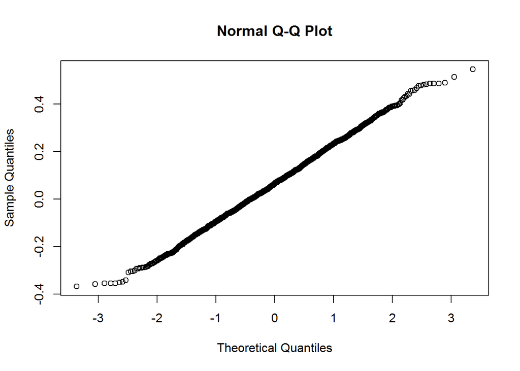

```r
qqnorm(logTL)
```

Log transformed RLTL data are closer to normality and will be used for statistical analyses.

Now it is checked, how many animals were in each feeding and genetic group:

```r
# creates data frame with only a single row for each animal (=EAR_TAG)
udata<-data[!duplicated(data$EAR_TAG),]
nrow(udata) #total number of animals in the complete cow data set
```

```
## [1] 308
```

```r
count(udata$BirthYear)
```

```
##      x freq
## 1 2008   25
## 2 2009   90
## 3 2010   89
## 4 2011   70
## 5 2012   28
## 6 2013    4
## 7 2014    2
```

```r
count(udata$BirthSeason)
```

```
##   x freq
## 1 1  152
## 2 2  156
```

```r
summary(udata$GENETIC_GROUP) # number of animals per genetic group
```

```
##   C   S
## 173 135
```

```r
summary(udata$FEED_GROUP)    # number of animasl in feeding groups
```

```
##    1    2 NULL
##  118  110   80
```

```r
#creates data frame that only contains animals of the selected line in feed group 1
SLF<-subset(udata, udata$GENETIC_GROUP=="S" & udata$FEED_GROUP =="1")
nrow(SLF) #number of selected cows in feed group 1
```

```
## [1] 58
```

```r
#creates data frame that only contains animals of the selected line in feed group 2
SHF<-subset(udata, udata$GENETIC_GROUP=="S" & udata$FEED_GROUP =="2")
nrow(SHF) #number of selected cows in feed group 2
```

```
## [1] 57
```

```r
#creates data frame that only contains animals of the selected line in NO feed group
SNull<-subset(udata, udata$GENETIC_GROUP=="S" & udata$FEED_GROUP =="NULL")
nrow(SNull) #number of selected cows not allocated to a feed group
```

```
## [1] 20
```

```r
#creates data frame that only contains animals of the control line in feed group 1
CLF<-subset(udata, udata$GENETIC_GROUP=="C" & udata$FEED_GROUP =="1")
nrow(CLF) #number of control cows in feed group 1
```

```
## [1] 60
```

```r
#creates data frame that only contains animals of the control line in feed group 2
CHF<-subset(udata, udata$GENETIC_GROUP=="C" & udata$FEED_GROUP =="2")
nrow(CHF) #number of control cows in feed group 2
```

```
## [1] 53
```

```r
#creates data frame that only contains animals of the control line in NO feed group
CNull<-subset(udata, udata$GENETIC_GROUP=="C" & udata$FEED_GROUP =="NULL")
nrow(CNull) #number of control cows not allocated to a feed group
```

```
## [1] 60
```

```r
#why were some animals not in feeding groups? Did they all die before reaching first lactation?
NG<-subset(udata, udata$FEED_GROUP == "NULL")
nrow(NG)
```

```
## [1] 80
```

```r
summary(as.numeric(paste(NG$PL)))
```

[output not shown]

```r
summary(as.numeric(paste(NG$HERD_LIFE)))
```

```
##    Min. 1st Qu.  Median    Mean 3rd Qu.    Max.    NA's
##    17.0   657.2   900.5  1089.4  1535.2  2452.0       8
```

```r
#No! That's not the reason. They reached an age that is too old to support that theory.

nrow(SLF)+nrow(SHF)+nrow(CLF)+nrow(CHF) #number of animals in feed and genetic groups
```

```
## [1] 228
```

```r
#culling depending on genetic or feed group?

S<-subset(data, data$GENETIC_GROUP == "S")
nrow(S)
```

```
## [1] 582
```

```r
C<-subset(data, data$GENETIC_GROUP == "C")
nrow(C)
```

```
## [1] 746
```

```r
S<-subset(S, S$HERD_LIFE != "NULL")
nrow(S)
```

```
## [1] 435
```

```r
C<-subset(C, C$HERD_LIFE != "NULL")
nrow(C)
```

```
## [1] 590
```

```r
uS<-S[!duplicated(S$EAR_TAG),]
nrow(uS)
```

```
## [1] 104
```

```r
uC<-C[!duplicated(C$EAR_TAG),]
nrow(uC)
```

```
## [1] 140
```

```r
t.test(as.numeric(paste(uS$HERD_LIFE)), as.numeric(paste(uC$HERD_LIFE)),var.equal = TRUE)
```

```
##
##  Two Sample t-test
##
## data:  as.numeric(paste(uS$HERD_LIFE)) and as.numeric(paste(uC$HERD_LIFE))
## t = -0.89543, df = 242, p-value = 0.3714
## alternative hypothesis: true difference in means is not equal to 0
## 95 percent confidence interval:
##  -224.34284   84.12196
## sample estimates:
## mean of x mean of y
##  1436.904  1507.014
```

```r
#There is no statistically significant difference in productive lifespan between the two genetic groups.

LF<-subset(data, data$FEED_GROUP == 1)
nrow(LF)
```

```
## [1] 526
```

```r
HF<-subset(data, data$FEED_GROUP == 2)
nrow(HF)
```

```
## [1] 524
```

```r
LF<-subset(LF, LF$HERD_LIFE != "NULL")
nrow(LF)
```

```
## [1] 467
```

```r
HF<-subset(HF, HF$HERD_LIFE != "NULL")
nrow(HF)
```

```
## [1] 318
```

```r
uLF<-LF[!duplicated(LF$EAR_TAG),]
nrow(uLF)
```

```
## [1] 105
```

```r
uHF<-HF[!duplicated(HF$EAR_TAG),]
nrow(uHF)
```

```
## [1] 67
```

```r
t.test(as.numeric(paste(uLF$HERD_LIFE)), as.numeric(paste(uHF$HERD_LIFE)),var.equal = TRUE)
```

```
##
##  Two Sample t-test
##
## data:  as.numeric(paste(uLF$HERD_LIFE)) and as.numeric(paste(uHF$HERD_LIFE))
## t = -1.1235, df = 170, p-value = 0.2628
## alternative hypothesis: true difference in means is not equal to 0
## 95 percent confidence interval:
##  -257.72843   70.77065
## sample estimates:
## mean of x mean of y
##  1603.029  1696.507
```

```r
#There is no statistically significant difference in productive lifespan between the two feeding groups.
```

To explore the data further, I am plotting some histograms

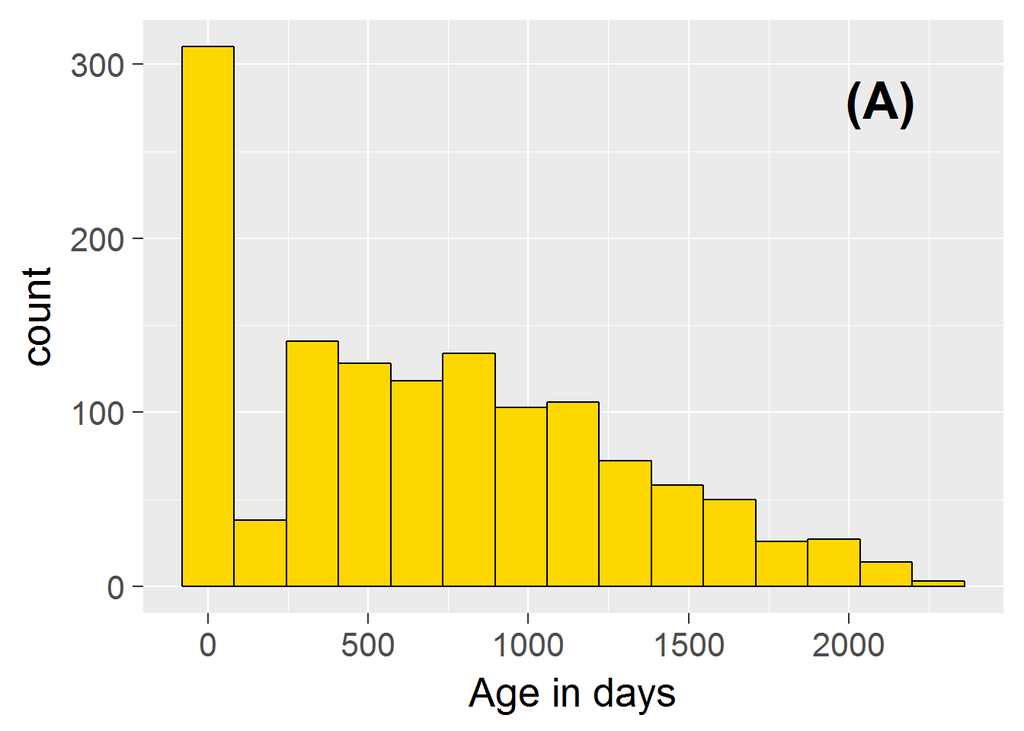

```r
#number of samples at specific ages measured in days:
m <- ggplot(data, aes(x=AGE_D)) +geom_histogram(bins=15, color= "black", fill="gold1")+ xlab("Age in days")+theme_gray(20)+guides(fill=F) + annotate("text", x = 2100, y = 280, label = "(A)",size=9, fontface = "bold")
m
```

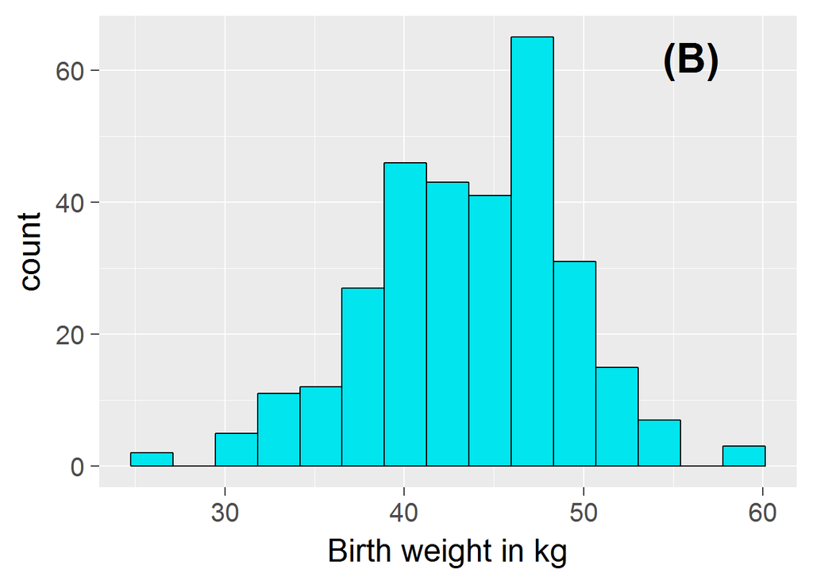

```r
#birth weight of the animals
n <- ggplot(udata, aes(x=BIRTH_WGT)) +geom_histogram(bins=15, color= "black", fill="turquoise2")+ xlab("Birth weight in kg")+theme_gray(20)+guides(fill=F)+ annotate("text", x = 56, y = 62, label = "(B)",size=9, fontface = "bold")
n
```

```r
#Live weigth
W<-as.numeric(paste(data$LIVE_WGT))
```

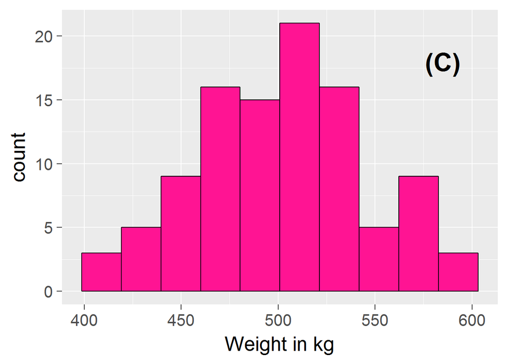

```r
o <- ggplot(data, aes(x=W)) +geom_histogram(bins=10, color= "black", fill="deeppink1")+ xlab("Weight in kg")+theme_gray(20)+guides(fill=F)+ annotate("text", x = 585, y = 18, label = "(C)",size=9, fontface = "bold")
o
```

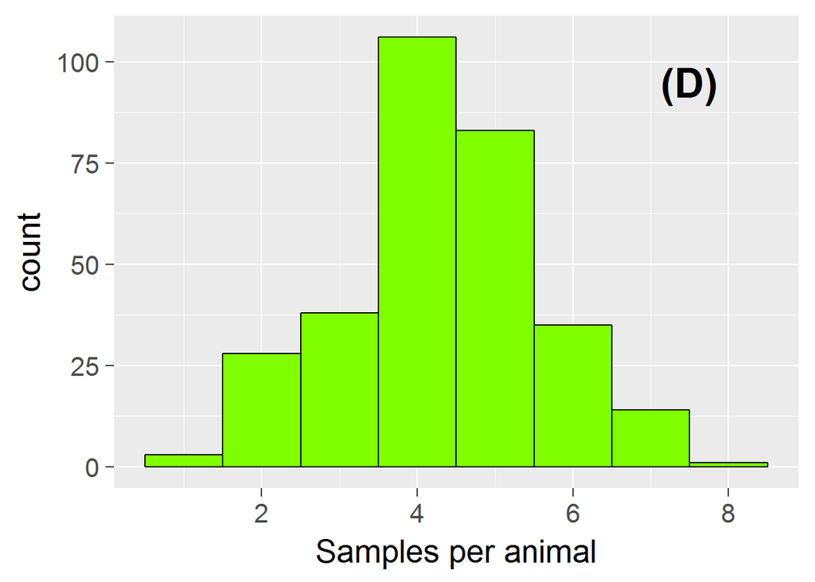

```r
# samples per animal
df<-data.frame(data$EAR_TAG)

count.dups <- function(DF){

  DT <- data.table(DF)
  DT[,.N, by = names(DT)]
}
samplePerAnimal<-count.dups(df)


p <- ggplot(samplePerAnimal, aes(x=N)) +geom_histogram(bins=8, color= "black", fill="chartreuse")+ xlab("Samples per animal")+theme_gray(20)+guides(fill=F)+ annotate("text", x = 7.5, y = 95, label = "(D)",size=9, fontface = "bold")
p
```

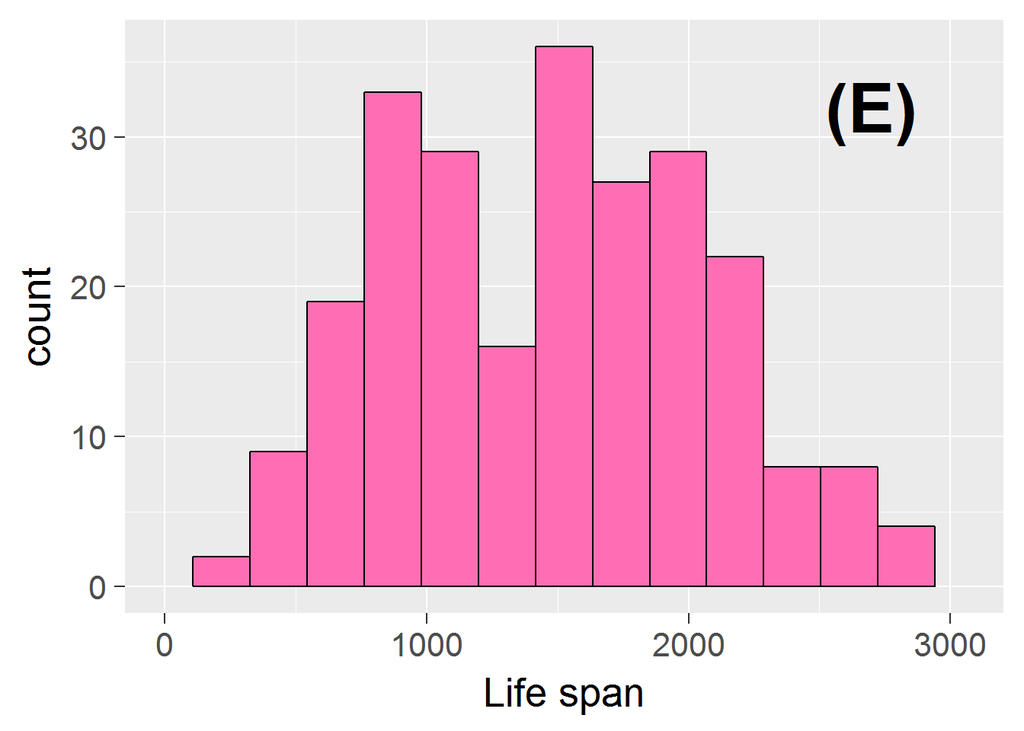

```r
#Herd life (time from birth to death in days)
q <- ggplot(udata, aes(x=as.numeric(paste(udata$HERD_LIFE)))) +geom_histogram(bins=15, color= "black", fill="hotpink1")+ xlab("Life span")+theme_gray(20)+guides(fill=F) + annotate("text", x = 2700, y = 32, label = "(E)",size=12, fontface = "bold")+xlim(0,3050)
q
```

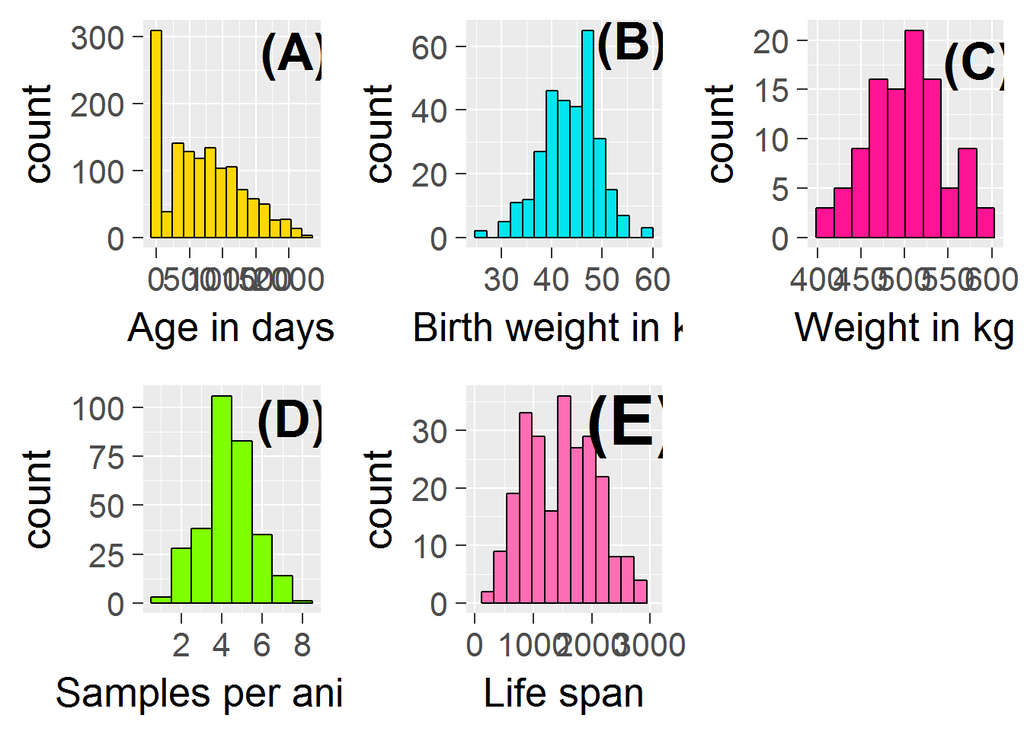

```r
grid.arrange(m,n,o,p, q, nrow=2)
```

Here, I was interested, how many animals had how many samples:

```r
single<-subset(samplePerAnimal, samplePerAnimal$N ==1)
nrow(single)
```

```
## [1] 3
```

```r
#after quality control three animals have no longer longitudinal samples...

two<-subset(samplePerAnimal, samplePerAnimal$N ==2)
nrow(two)
```

```
## [1] 28
```

```r
three<-subset(samplePerAnimal, samplePerAnimal$N ==3)
nrow(three)
```

```
## [1] 38
```

```r
four<-subset(samplePerAnimal, samplePerAnimal$N ==4)
nrow(four)
```

```
## [1] 106
```

```r
five<-subset(samplePerAnimal, samplePerAnimal$N ==5)
nrow(five)
```

```
## [1] 83
```

```r
six<-subset(samplePerAnimal, samplePerAnimal$N ==6)
nrow(six)
```

```
## [1] 35
```

```r
seven<-subset(samplePerAnimal, samplePerAnimal$N ==7)
nrow(seven)
```

```
## [1] 14
```

```r
eight<-subset(samplePerAnimal, samplePerAnimal$N ==8)
nrow(eight)
```

```
## [1] 1
```

Reasons for culling and survival analysis

REASON FOR DEATH

How many animals died from which reason?

```r
dData<-subset(data, data$CULL_DATE!= "NULL")
nrow(dData)# numberof samples of dead animals
```

```
## [1] 1025
```

```r
duData<-dData[!duplicated(dData$EAR_TAG),]
nrow(duData) # total number of animals with cull date
```

```
## [1] 244
```

```r
summary(duData$CULL_REASON)
```

```
##              ACCIDENT           BAD CALVING   BRUCELLOSIS/ABORTED
##                    28                     3                     5
##                  DIED     FOOT/LEG PROBLEMS              HIGH SCC
##                    12                    34                     2
##         LOST QUARTERS              MASTITIS      NOT SEEN IN HEAT
##                     4                    29                     1
##   NOT SERVED - POLICY                  NULL         OTHER/SURPLUS
##                     7                    16                    25
##    POOR YIELD/NO MILK      REASON NOT GIVEN        REPEAT BREEDER
##                     2                     2                    40
## REPRODUCTIVE DISORDER               UNKNOWN
##                    28                     6
```

```r
summary(duData$CULL_GROUP)
```

```
##    F    L    M NULL    O    P
##   77   34   35   19   77    2
```

```r
#adds column for involuntary vs. voluntary culling
duData$CULL_Reason_Group <- ifelse(duData$CULL_REASON == "OTHER/SURPLUS" | duData$CULL_REASON == "NOT SERVED - POLICY" ,"Voluntary", ifelse(duData$CULL_REASON == "NULL" | duData$CULL_REASON == "UNKNOWN" | duData$CULL_REASON == "REASON NOT GIVEN", "Unrecorded", "Involuntary"))

summary(as.factor(duData$CULL_Reason_Group))
```

```
## Involuntary  Unrecorded   Voluntary
##         188          24          32
```

4. plots of RLTL measurements over age:

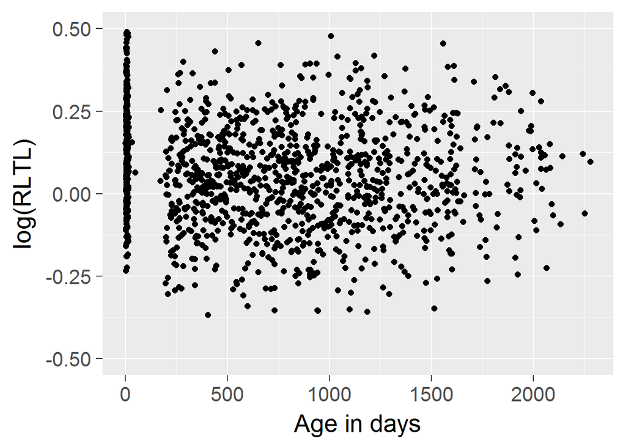

```r
# plot shows log(RTL) over age in days of animals
AgeP<-ggplot(data, aes(x=AGE_D, y=log(QC_RTL)))+ geom_point(size=2)+ xlab("Age in days")+ ylab("log(RLTL)")+theme_gray(20)+ylim(-0.5,0.5)
AgeP
```

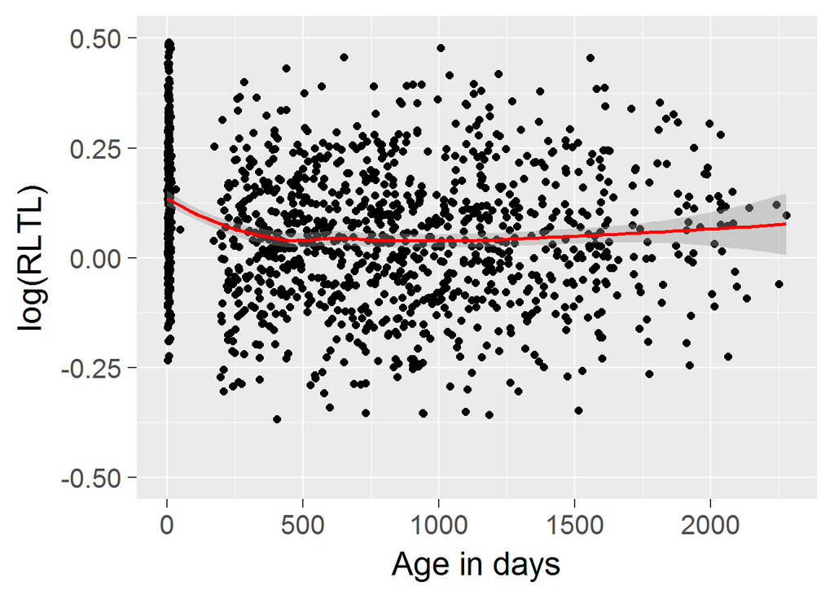

```r
# plot shows log(RTL) over age in days of animals
AgeP3<-ggplot(data, aes(x=AGE_D, y=log(data$QC_RTL)))+ geom_point(size=2)+ xlab("Age in days")+ ylab("log(RLTL)")+theme_gray(20)+ stat_smooth(method = "loess", formula = y ~ x, size = 1, colour = "red")+ylim(-0.5, 0.5)
AgeP3
```

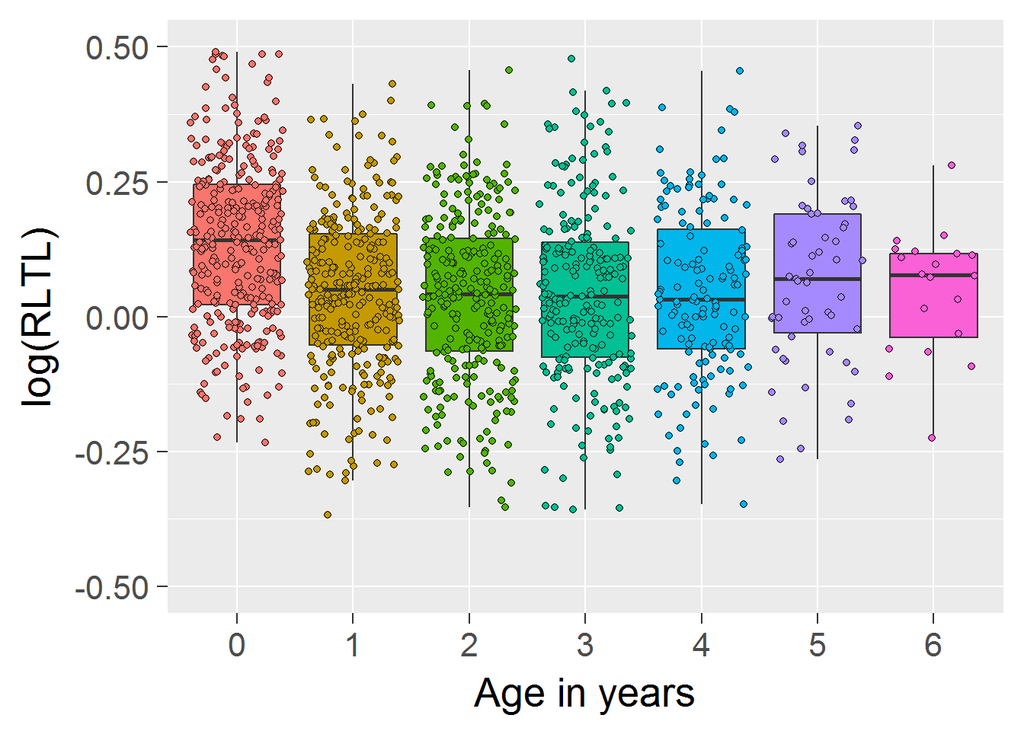

```r
# box and whisker plot with log(RLTL), age rounded to years
AgeInYears<-as.factor(data$AGE_Y)


boxPlot2<-ggplot(data, aes(x=AgeInYears, y = log(QC_RTL), fill=AgeInYears), na.action=na.exclude) + geom_boxplot(outlier.colour=NA,notch=F) + geom_jitter(shape=21,colour="black", size=1.5) + xlab("Age in years")+ylab("log(RLTL)")+theme_gray(20)+guides(fill=F)+ylim(-0.5, 0.5)

boxPlot2
```

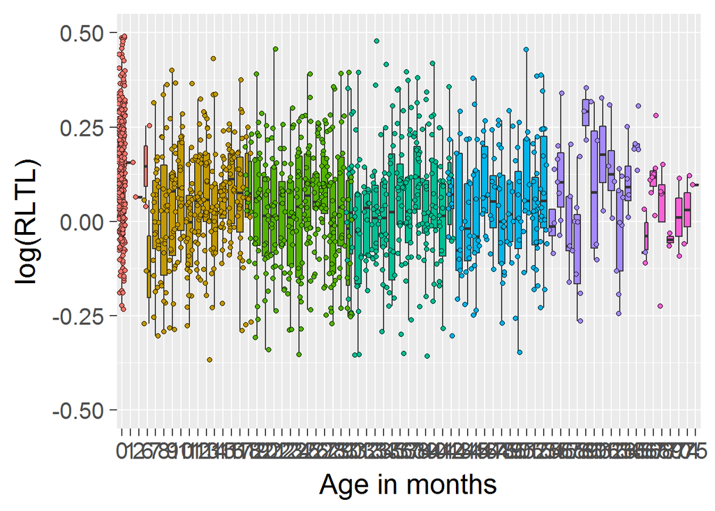

```r
AgeInMonths<-as.factor(data$AGE_M)

boxPlot2<-ggplot(data, aes(x=AgeInMonths, y = log(data$QC_RTL), fill=AgeInYears), na.action=na.exclude) + geom_boxplot(outlier.colour=NA,notch=F) + geom_jitter(shape=21,colour="black", size=1.5) + xlab("Age in months")+ylab("log(RLTL)")+theme_gray(20)+guides(fill=F)+ylim(-0.5, 0.5)

boxPlot2
```

5. Mixed models for the analysis of RLTL

First a null model is fitted that only contains the animal as random effect and qPCR plate and row as fixed effects. This model is used to compare all other models to that have an additional fixed effect of age added. Different functions of age are considered.

```r
mod0<-lmer(log(data$QC_RTL)~as.factor(data$Plate) + as.factor(data$Row) + (1|as.factor(data$EAR_TAG)), na.action=na.exclude)

#summary(mod0)
anova(mod0)
```

```
## Analysis of Variance Table of type III  with  Satterthwaite
## approximation for degrees of freedom
##                       Sum Sq Mean Sq NumDF  DenDF F.value    Pr(>F)
## as.factor(data$Plate) 1.7324 0.07218    24 1155.5  4.8751 2.056e-13 ***
## as.factor(data$Row)   3.0028 0.42897     7 1159.6 28.9715 < 2.2e-16 ***
## ---
## Signif. codes:  0 '***' 0.001 '**' 0.01 '*' 0.05 '.' 0.1 ' ' 1
```

```r
#calculate the repeatability for the null model
mod0out<-as.data.frame(VarCorr(mod0),comp=c("Variance", "Std.Dev."))
repET<-mod0out[1,4]/sum(mod0out[1:nrow(mod0out), 4])
repET
```

```
## [1] 0.3459453
```

```r
AIC(logLik(mod0))
```

```
## [1] -1228.914
```

Age in days is tested as fixed effect:

```r
#Model1
mod1<-lmer(log(data$QC_RTL)~ as.factor(data$Plate) + as.factor(data$Row)+ data$AGE_D + as.factor(data$BirthYear) + (1|as.factor(data$EAR_TAG)), na.action=na.exclude)

#summary(mod1)
anova(mod1)
```

```
## Analysis of Variance Table of type III  with  Satterthwaite
## approximation for degrees of freedom
##                            Sum Sq Mean Sq NumDF   DenDF F.value    Pr(>F)
## as.factor(data$Plate)     1.64883 0.06870    24 1146.83   4.972 8.771e-14
## as.factor(data$Row)       3.05590 0.43656     7 1149.87  31.596 < 2.2e-16
## data$AGE_D                1.00337 1.00337     1 1053.05  72.620 < 2.2e-16
## as.factor(data$BirthYear) 0.32229 0.05371     6  372.12   3.888 0.0008865
##
## as.factor(data$Plate)     ***
## as.factor(data$Row)       ***
## data$AGE_D                ***
## as.factor(data$BirthYear) ***
## ---
## Signif. codes:  0 '***' 0.001 '**' 0.01 '*' 0.05 '.' 0.1 ' ' 1
```

```r
anova(mod0, mod1) #compares model to null model
```

```
## refitting model(s) with ML (instead of REML)
```

```
## Data: NULL
## Models:
## object: log(data$QC_RTL) ~ as.factor(data$Plate) + as.factor(data$Row) +
## object:     (1 | as.factor(data$EAR_TAG))
## ..1: log(data$QC_RTL) ~ as.factor(data$Plate) + as.factor(data$Row) +
## ..1:     data$AGE_D + as.factor(data$BirthYear) + (1 | as.factor(data$EAR_TAG))
##        Df     AIC     BIC logLik deviance  Chisq Chi Df Pr(>Chisq)
## object 34 -1431.4 -1254.9 749.72  -1499.4
## ..1    41 -1508.2 -1295.3 795.08  -1590.2 90.711      7  < 2.2e-16 ***
## ---
## Signif. codes:  0 '***' 0.001 '**' 0.01 '*' 0.05 '.' 0.1 ' ' 1
```

```r
AIC(logLik(mod1))
```

```
## [1] -1249.948
```

```r
#linear polynomial

mod1lin<-lmer(log(data$QC_RTL)~ as.factor(data$Plate) + as.factor(data$Row)+ poly(data$AGE_D,1) + as.factor(data$BirthYear) + (1|as.factor(data$EAR_TAG)), na.action=na.exclude)

#summary(mod1)
anova(mod1lin)
```

```
## Analysis of Variance Table of type III  with  Satterthwaite
## approximation for degrees of freedom
##                            Sum Sq Mean Sq NumDF   DenDF F.value    Pr(>F)
## as.factor(data$Plate)     1.64883 0.06870    24 1146.83   4.972 8.771e-14
## as.factor(data$Row)       3.05590 0.43656     7 1149.87  31.596 < 2.2e-16
## poly(data$AGE_D, 1)       1.00337 1.00337     1 1053.05  72.620 < 2.2e-16
## as.factor(data$BirthYear) 0.32229 0.05371     6  372.12   3.888 0.0008865
##
## as.factor(data$Plate)     ***
## as.factor(data$Row)       ***
## poly(data$AGE_D, 1)       ***
## as.factor(data$BirthYear) ***
## ---
## Signif. codes:  0 '***' 0.001 '**' 0.01 '*' 0.05 '.' 0.1 ' ' 1
```

```r
anova(mod0, mod1lin) #compares model to null model
```

```
## refitting model(s) with ML (instead of REML)
```

```
## Data: NULL
## Models:
## object: log(data$QC_RTL) ~ as.factor(data$Plate) + as.factor(data$Row) +
## object:     (1 | as.factor(data$EAR_TAG))
## ..1: log(data$QC_RTL) ~ as.factor(data$Plate) + as.factor(data$Row) +
## ..1:     poly(data$AGE_D, 1) + as.factor(data$BirthYear) + (1 | as.factor(data$EAR_TAG))
##        Df     AIC     BIC logLik deviance  Chisq Chi Df Pr(>Chisq)
## object 34 -1431.4 -1254.9 749.72  -1499.4
## ..1    41 -1508.2 -1295.3 795.08  -1590.2 90.711      7  < 2.2e-16 ***
## ---
## Signif. codes:  0 '***' 0.001 '**' 0.01 '*' 0.05 '.' 0.1 ' ' 1
```

```r
AIC(logLik(mod1lin))
```

[output not shown]

```r
anova(mod1, mod1lin)
```

```
## refitting model(s) with ML (instead of REML)
```

```
## Data: NULL
## Models:
## object: log(data$QC_RTL) ~ as.factor(data$Plate) + as.factor(data$Row) +
## object:     data$AGE_D + as.factor(data$BirthYear) + (1 | as.factor(data$EAR_TAG))
## ..1: log(data$QC_RTL) ~ as.factor(data$Plate) + as.factor(data$Row) +
## ..1:     poly(data$AGE_D, 1) + as.factor(data$BirthYear) + (1 | as.factor(data$EAR_TAG))
##        Df     AIC     BIC logLik deviance Chisq Chi Df Pr(>Chisq)
## object 41 -1508.2 -1295.3 795.08  -1590.2
## ..1    41 -1508.2 -1295.3 795.08  -1590.2     0      0  < 2.2e-16 ***
## ---
## Signif. codes:  0 '***' 0.001 '**' 0.01 '*' 0.05 '.' 0.1 ' ' 1
```

Because the relationship between RLTL and age seems not to be linear for the cow group, polynomials of increasing order are fitted as functions of age in days to capture the dynamics better.

```r
#Model2: second order (quadratic) polynomial
mod2<-lmer(log(data$QC_RTL)~ as.factor(data$Plate) + as.factor(data$Row)+ poly(data$AGE_D,2) + as.factor(data$BirthYear)+ (1|as.factor(data$EAR_TAG)), na.action=na.exclude)

#summary(mod2)
anova(mod2)
```

```
## Analysis of Variance Table of type III  with  Satterthwaite
## approximation for degrees of freedom
##                            Sum Sq Mean Sq NumDF   DenDF F.value    Pr(>F)
## as.factor(data$Plate)     1.76597 0.07358    24 1136.77   5.700 < 2.2e-16
## as.factor(data$Row)       3.02014 0.43145     7 1139.48  33.424 < 2.2e-16
## poly(data$AGE_D, 2)       1.90212 0.95106     2 1041.71  73.677 < 2.2e-16
## as.factor(data$BirthYear) 0.22772 0.03795     6  369.32   2.940  0.008159
##
## as.factor(data$Plate)     ***
## as.factor(data$Row)       ***
## poly(data$AGE_D, 2)       ***
## as.factor(data$BirthYear) **
## ---
## Signif. codes:  0 '***' 0.001 '**' 0.01 '*' 0.05 '.' 0.1 ' ' 1
```

```r
anova(mod0, mod2)
```

```
## refitting model(s) with ML (instead of REML)
```

```
## Data: NULL
## Models:
## object: log(data$QC_RTL) ~ as.factor(data$Plate) + as.factor(data$Row) +
## object:     (1 | as.factor(data$EAR_TAG))
## ..1: log(data$QC_RTL) ~ as.factor(data$Plate) + as.factor(data$Row) +
## ..1:     poly(data$AGE_D, 2) + as.factor(data$BirthYear) + (1 | as.factor(data$EAR_TAG))
##        Df     AIC     BIC logLik deviance  Chisq Chi Df Pr(>Chisq)
## object 34 -1431.4 -1254.9 749.72  -1499.4
## ..1    42 -1575.4 -1357.4 829.72  -1659.4 160.01      8  < 2.2e-16 ***
## ---
## Signif. codes:  0 '***' 0.001 '**' 0.01 '*' 0.05 '.' 0.1 ' ' 1
```

```r
AIC(logLik(mod2))
```

```
## [1] -1332.677
```

```r
#Model3: third order polynomial
mod3<-lmer(log(data$QC_RTL)~ as.factor(data$Plate) + as.factor(data$Row)+ poly(data$AGE_D,3) + as.factor(data$BirthYear)+ (1|as.factor(data$EAR_TAG)), na.action=na.exclude)

anova(mod3)
```

```
## Analysis of Variance Table of type III  with  Satterthwaite
## approximation for degrees of freedom
##                           Sum Sq Mean Sq NumDF   DenDF F.value    Pr(>F)
## as.factor(data$Plate)     1.7587 0.07328    24 1133.11   5.812 < 2.2e-16
## as.factor(data$Row)       3.0261 0.43229     7 1135.69  34.287 < 2.2e-16
## poly(data$AGE_D, 3)       2.2132 0.73772     3 1035.32  58.511 < 2.2e-16
## as.factor(data$BirthYear) 0.2250 0.03750     6  368.77   2.974  0.007548
##
## as.factor(data$Plate)     ***
## as.factor(data$Row)       ***
## poly(data$AGE_D, 3)       ***
## as.factor(data$BirthYear) **
## ---
## Signif. codes:  0 '***' 0.001 '**' 0.01 '*' 0.05 '.' 0.1 ' ' 1
```

```r
anova(mod0, mod3)
```

```
## refitting model(s) with ML (instead of REML)
```

```
## Data: NULL
## Models:
## object: log(data$QC_RTL) ~ as.factor(data$Plate) + as.factor(data$Row) +
## object:     (1 | as.factor(data$EAR_TAG))
## ..1: log(data$QC_RTL) ~ as.factor(data$Plate) + as.factor(data$Row) +
## ..1:     poly(data$AGE_D, 3) + as.factor(data$BirthYear) + (1 | as.factor(data$EAR_TAG))
##        Df     AIC     BIC logLik deviance  Chisq Chi Df Pr(>Chisq)
## object 34 -1431.4 -1254.9 749.72  -1499.4
## ..1    43 -1598.6 -1375.3 842.28  -1684.6 185.13      9  < 2.2e-16 ***
## ---
## Signif. codes:  0 '***' 0.001 '**' 0.01 '*' 0.05 '.' 0.1 ' ' 1
```

```r
AIC(logLik(mod3))
```

```
## [1] -1352.577
```

```r
#Model4: forth order polynomial
mod4<-lmer(log(data$QC_RTL)~ as.factor(data$Plate) + as.factor(data$Row)+ poly(data$AGE_D,4) + as.factor(data$BirthYear)+ (1|as.factor(data$EAR_TAG)), na.action=na.exclude)

anova(mod4)
```

```
## Analysis of Variance Table of type III  with  Satterthwaite
## approximation for degrees of freedom
##                            Sum Sq Mean Sq NumDF   DenDF F.value    Pr(>F)
## as.factor(data$Plate)     1.77877 0.07412    24 1132.18   5.911 < 2.2e-16
## as.factor(data$Row)       3.07054 0.43865     7 1134.59  34.984 < 2.2e-16
## poly(data$AGE_D, 4)       2.31651 0.57913     4 1033.09  46.188 < 2.2e-16
## as.factor(data$BirthYear) 0.23078 0.03846     6  369.11   3.068  0.006089
##
## as.factor(data$Plate)     ***
## as.factor(data$Row)       ***
## poly(data$AGE_D, 4)       ***
## as.factor(data$BirthYear) **
## ---
## Signif. codes:  0 '***' 0.001 '**' 0.01 '*' 0.05 '.' 0.1 ' ' 1
```

```r
anova(mod0, mod4)
```

```
## refitting model(s) with ML (instead of REML)
```

```
## Data: NULL
## Models:
## object: log(data$QC_RTL) ~ as.factor(data$Plate) + as.factor(data$Row) +
## object:     (1 | as.factor(data$EAR_TAG))
## ..1: log(data$QC_RTL) ~ as.factor(data$Plate) + as.factor(data$Row) +
## ..1:     poly(data$AGE_D, 4) + as.factor(data$BirthYear) + (1 | as.factor(data$EAR_TAG))
##        Df     AIC     BIC logLik deviance  Chisq Chi Df Pr(>Chisq)
## object 34 -1431.4 -1254.9 749.72  -1499.4
## ..1    44 -1605.0 -1376.6 846.53  -1693.0 193.61     10  < 2.2e-16 ***
## ---
## Signif. codes:  0 '***' 0.001 '**' 0.01 '*' 0.05 '.' 0.1 ' ' 1
```

```r
AIC(logLik(mod4))
```

```
## [1] -1356.361
```

```r
#age as factor with two levels: level 1 are measurments within the first two months of live, level 2 are measurements at the age of 6 months or later

mod5<-lmer(log(data$QC_RTL)~ as.factor(data$Plate) + as.factor(data$Row)+ as.factor(data$AgeGr)+ data$BirthYear + (1|as.factor(data$EAR_TAG)), na.action=na.exclude)

anova(mod5)
```

```
## Analysis of Variance Table of type III  with  Satterthwaite
## approximation for degrees of freedom
##                        Sum Sq Mean Sq NumDF   DenDF F.value  Pr(>F)
## as.factor(data$Plate) 1.78532 0.07439    24 1133.73   6.020 < 2e-16 ***
## as.factor(data$Row)   3.12781 0.44683     7 1136.79  36.163 < 2e-16 ***
## as.factor(data$AgeGr) 2.50290 2.50290     1 1016.23 202.565 < 2e-16 ***
## data$BirthYear        0.04568 0.04568     1  345.38   3.697 0.05534 .
## ---
## Signif. codes:  0 '***' 0.001 '**' 0.01 '*' 0.05 '.' 0.1 ' ' 1
```

```r
anova(mod0, mod5)
```

```
## refitting model(s) with ML (instead of REML)
```

```
## Data: NULL
## Models:
## object: log(data$QC_RTL) ~ as.factor(data$Plate) + as.factor(data$Row) +
## object:     (1 | as.factor(data$EAR_TAG))
## ..1: log(data$QC_RTL) ~ as.factor(data$Plate) + as.factor(data$Row) +
## ..1:     as.factor(data$AgeGr) + data$BirthYear + (1 | as.factor(data$EAR_TAG))
##        Df     AIC     BIC logLik deviance  Chisq Chi Df Pr(>Chisq)
## object 34 -1431.4 -1254.9 749.72  -1499.4
## ..1    36 -1618.8 -1431.9 845.41  -1690.8 191.39      2  < 2.2e-16 ***
## ---
## Signif. codes:  0 '***' 0.001 '**' 0.01 '*' 0.05 '.' 0.1 ' ' 1
```

```r
AIC(logLik(mod5))
```

```
## [1] -1394.439
```

To find the ideal cutoff age for a factor with two levels all possible cutoffs are tested:

```r
i=1
j=1

df<-data.frame()

for (i in 1:75){
 data$newcol<-0
 colnames(data)[which(names(data) == "newcol")] <- paste("M", i, sep="_")
 data[,ncol(data)] <- ifelse(data$AGE_M <i, 1, 2)
 mod<-lmer(log(data$QC_RTL)~ as.factor(data$Plate) + as.factor(data$Row)+ as.factor(data$BirthYear)+ as.factor(data[,ncol(data)]) + (1|as.factor(data$EAR_TAG)), na.action=na.exclude)
 x<-anova(mod0, mod)
 y<-as.data.frame(x["AIC"])
 z<-y[2,1]
 df[j, 1]<-z
 i<-i+1
 j=j+1
}
```

[output not shown]

[output cut: 20 more lines]

[output not shown]

```r
names(df)<-"AIC"
df$AGE_M<-c(1:75)

sdf<-df[order(df$AIC),]

sdf
```

```
##          AIC AGE_M
## 1  -1625.131     1
## 3  -1624.301     3
## 4  -1624.301     4
## 5  -1624.301     5
## 6  -1624.301     6
## 2  -1623.707     2
## 7  -1615.915     7
## 8  -1591.344     8
## 9  -1574.943     9
## 10 -1554.280    10
## 11 -1554.271    11
## 12 -1535.605    12
## 13 -1525.906    13
## 14 -1521.794    14
```

[output cut: 61 more lines]

```r
#to save this dataframe:
#write.csv(sdf, "C:/Users/lseeker/Documents/PhD/Stage1_Experiment/07_Analysis/03_ExploreNewDF/20180110_AgeAsFactorTestCutOff.csv")


#best fitting model is where the factor for age describes animals that are younger or >= 1 month of age:

modFin<-lmer(log(data$QC_RTL)~ as.factor(data$Plate) + as.factor(data$Row)+  as.factor(data$BirthYear) + as.factor(data$M_1) + (1|as.factor(data$EAR_TAG)), na.action=na.exclude)

summary(modFin)
```

```
## Linear mixed model fit by REML t-tests use Satterthwaite approximations
##   to degrees of freedom [lmerMod]
## Formula: log(data$QC_RTL) ~ as.factor(data$Plate) + as.factor(data$Row) +
##     as.factor(data$BirthYear) + as.factor(data$M_1) + (1 | as.factor(data$EAR_TAG))
##
## REML criterion at convergence: -1459.8
##
## Scaled residuals:
##      Min       1Q   Median       3Q      Max
## -2.28341 -0.63190 -0.03923  0.62061  2.59478
##
## Random effects:
##  Groups                  Name        Variance Std.Dev.
##  as.factor(data$EAR_TAG) (Intercept) 0.007895 0.08885
##  Residual                            0.012345 0.11111
## Number of obs: 1328, groups:  as.factor(data$EAR_TAG), 308
##
## Fixed effects:
##                                 Estimate Std. Error         df t value
## (Intercept)                    1.037e-01  2.813e-02  7.445e+02   3.686
## as.factor(data$Plate)2         2.501e-02  2.309e-02  1.149e+03   1.083
## as.factor(data$Plate)3         2.118e-02  2.326e-02  1.157e+03   0.910
## as.factor(data$Plate)4         8.526e-03  2.353e-02  1.154e+03   0.362
## as.factor(data$Plate)5        -5.391e-03  2.323e-02  1.151e+03  -0.232
## as.factor(data$Plate)6        -9.444e-03  2.330e-02  1.159e+03  -0.405
## as.factor(data$Plate)7         1.214e-02  2.348e-02  1.148e+03   0.517
## as.factor(data$Plate)8        -3.795e-03  2.302e-02  1.138e+03  -0.165
## as.factor(data$Plate)9        -6.961e-03  2.330e-02  1.128e+03  -0.299
## as.factor(data$Plate)10        3.461e-02  2.304e-02  1.141e+03   1.502
## as.factor(data$Plate)11        1.357e-02  2.314e-02  1.156e+03   0.586
## as.factor(data$Plate)12        3.618e-02  2.332e-02  1.156e+03   1.551
## as.factor(data$Plate)13        6.154e-02  2.323e-02  1.142e+03   2.649
## as.factor(data$Plate)14        4.659e-02  2.312e-02  1.139e+03   2.015
## as.factor(data$Plate)15       -4.362e-03  2.359e-02  1.161e+03  -0.185
## as.factor(data$Plate)16        1.764e-02  2.344e-02  1.152e+03   0.753
## as.factor(data$Plate)17        1.557e-01  2.320e-02  1.155e+03   6.710
## as.factor(data$Plate)18        1.025e-01  2.323e-02  1.155e+03   4.413
## as.factor(data$Plate)19        5.281e-02  2.327e-02  1.131e+03   2.269
## as.factor(data$Plate)20        1.526e-02  2.338e-02  1.161e+03   0.653
## as.factor(data$Plate)21        2.935e-02  2.343e-02  1.146e+03   1.252
```

[output cut: 45 more lines]

```
## as.factor(data$Row)C          1.60e-07 ***
## as.factor(data$Row)D          1.97e-08 ***
## as.factor(data$Row)E          0.878036
## as.factor(data$Row)F          0.246937
## as.factor(data$Row)G          0.032164 *
## as.factor(data$Row)H          0.291417
## as.factor(data$BirthYear)2009 0.123189
## as.factor(data$BirthYear)2010 0.291286
## as.factor(data$BirthYear)2011 0.707505
## as.factor(data$BirthYear)2012 0.480312
## as.factor(data$BirthYear)2013 0.232818
## as.factor(data$BirthYear)2014 0.597500
## as.factor(data$M_1)2           < 2e-16 ***
## ---
## Signif. codes:  0 '***' 0.001 '**' 0.01 '*' 0.05 '.' 0.1 ' ' 1
```

```
##
## Correlation matrix not shown by default, as p = 39 > 12.
## Use print(x, correlation=TRUE)  or
##   vcov(x)     if you need it
```

```r
anova(modFin)
```

```
## Analysis of Variance Table of type III  with  Satterthwaite
## approximation for degrees of freedom
##                            Sum Sq Mean Sq NumDF   DenDF F.value    Pr(>F)
## as.factor(data$Plate)     1.78749 0.07448    24 1133.88   6.033 < 2.2e-16
## as.factor(data$Row)       3.11422 0.44489     7 1136.53  36.038 < 2.2e-16
## as.factor(data$BirthYear) 0.23938 0.03990     6  363.89   3.232  0.004172
## as.factor(data$M_1)       2.48615 2.48615     1 1012.86 201.387 < 2.2e-16
##
## as.factor(data$Plate)     ***
## as.factor(data$Row)       ***
## as.factor(data$BirthYear) **
## as.factor(data$M_1)       ***
## ---
## Signif. codes:  0 '***' 0.001 '**' 0.01 '*' 0.05 '.' 0.1 ' ' 1
```

```r
AIC(logLik(modFin))
```

```
## [1] -1377.755
```

```r
anova(mod0, modFin)
```

```
## refitting model(s) with ML (instead of REML)
```

```
## Data: NULL
## Models:
## object: log(data$QC_RTL) ~ as.factor(data$Plate) + as.factor(data$Row) +
## object:     (1 | as.factor(data$EAR_TAG))
## ..1: log(data$QC_RTL) ~ as.factor(data$Plate) + as.factor(data$Row) +
## ..1:     as.factor(data$BirthYear) + as.factor(data$M_1) + (1 | as.factor(data$EAR_TAG))
##        Df     AIC     BIC logLik deviance  Chisq Chi Df Pr(>Chisq)
## object 34 -1431.4 -1254.9 749.72  -1499.4
## ..1    41 -1625.1 -1412.3 853.57  -1707.1 207.69      7  < 2.2e-16 ***
## ---
## Signif. codes:  0 '***' 0.001 '**' 0.01 '*' 0.05 '.' 0.1 ' ' 1
```

```r
modFinout<-as.data.frame(VarCorr(modFin),comp=c("Variance", "Std.Dev."))
repET<-modFinout[1,4]/sum(modFinout[1:nrow(modFinout), 4])
repET
```

```
## [1] 0.3900631
```

```r
x<-coef(summary(modFin))
dfx<-as.data.frame(x)

#write.csv(dfx, "C:/Users/lseeker/Documents/PhD/Stage1_Experiment/07_Analysis/03_ExploreNewDF/20180110_FixedEffSize.csv")



# calculate R2 for final model:
r2.corr.mer <- function(m) {
  lmfit <-  lm(model.response(model.frame(m)) ~ fitted(m))
  summary(lmfit)$r.squared
}

r2.corr.mer(modFin)
```

```
## [1] 0.6280833
```

```r
1-var(residuals(modFin))/(var(model.response(model.frame(modFin))))
```

```
## [1] 0.6152142
```